# Binary Logistic Regression using R

Ruth Ogal

2024-09-07

## Dataset Information

The Adult dataset (Becker and Kohavi 1996), accessible from the [UCI Machine Learning Repository](https://archive.ics.uci.edu/dataset/2/adult), is a sample from the 1994 US census database comprising 15 variables. A description of each variable is given in Table 1.

| Variable | Description |
| --- | --- |
| age | Age |
| workclass | Employment status |
| fnlwgt | Final weight, i.e., the number of people in a given row |
| education | Highest level of education |
| education-num | Highest level of education in numerical form |
| marital_status | Marital status |
| occupation | Occupation |
| relationship | Family relationship |
| race | Race |
| sex | Sex/gender |
| capital_gain | Capital gain for an individual |
| capital_loss | Capital loss for an individual |
| hours_per_week | Working hours per week |
| native_country | Country of birth |
| income | Whether an individual makes more than $50,000 annually |

Table 1: Description of Adult dataset variables.

**Objective:** Use logistic regression to build a model that predicts a person’s income group, categorized as <=50K or >50K.

As we have already downloaded the data, we load it in R using the code below. The dataset consists of two parts: the training set, `adult.data`, and the test set, `adult.test`. We start by loading the training set, which is vital for exploration exercises.

```r
# Read train data
train_data <- read.csv("C:/Users/User/Desktop/Logistic_Regression_ADULT/Data/adult.data", header = FALSE, sep = ",", strip.white = TRUE, stringsAsFactors = TRUE)
# Name columns
names(train_data) <- c("age", "workclass", "fnlwgt", "education", "education_num", "marital_status", "occupation", "relationship", "race", "sex", "capital_gain", "capital_loss", "hours_per_week", "native_country", "income")
```

## Exploratory Data Analysis

Logistic regression makes the following assumptions about the data:

- The target variable is binary.
- Absence of multicollinearity among the predictor variables.
- There are no outliers in the data.
- A linear relationship exists between continuous predictors and the logit of the outcome.

We perform exploratory data analysis (EDA) before building the model to check whether the data meets these assumptions. EDA also helps with feature selection and reveals possible relationships between variables.

**Task 1: Load required packages.**

```r
library(ggplot2)
library(cowplot)
library(caret)
library(dplyr)
```

**Task 2: Determine the internal structure of the dataset.**

We use the `str()` function to gain an overview of the dataset. This function provides information on dataset properties like dimension and data types.

```r
str(train_data)
```

```
'data.frame':   32561 obs. of  15 variables:
 $ age           : int  39 50 38 53 28 37 49 52 31 42 ...
 $ workclass     : Factor w/ 9 levels "?","Federal-gov",..: 8 7 5 5 5 5 5 7 5 5 ...
 $ fnlwgt        : int  77516 83311 215646 234721 338409 284582 160187 209642 45781 159449 ...
 $ education     : Factor w/ 16 levels "10th","11th",..: 10 10 12 2 10 13 7 12 13 10 ...
 $ education_num : int  13 13 9 7 13 14 5 9 14 13 ...
 $ marital_status: Factor w/ 7 levels "Divorced","Married-AF-spouse",..: 5 3 1 3 3 3 4 3 5 3 ...
 $ occupation    : Factor w/ 15 levels "?","Adm-clerical",..: 2 5 7 7 11 5 9 5 11 5 ...
 $ relationship  : Factor w/ 6 levels "Husband","Not-in-family",..: 2 1 2 1 6 6 2 1 2 1 ...
 $ race          : Factor w/ 5 levels "Amer-Indian-Eskimo",..: 5 5 5 3 3 5 3 5 5 5 ...
 $ sex           : Factor w/ 2 levels "Female","Male": 2 2 2 2 1 1 1 2 1 2 ...
 $ capital_gain  : int  2174 0 0 0 0 0 0 0 14084 5178 ...
 $ capital_loss  : int  0 0 0 0 0 0 0 0 0 0 ...
 $ hours_per_week: int  40 13 40 40 40 40 16 45 50 40 ...
 $ native_country: Factor w/ 42 levels "?","Cambodia",..: 40 40 40 40 6 40 24 40 40 40 ...
 $ income        : Factor w/ 2 levels "<=50K",">50K": 1 1 1 1 1 1 1 2 2 2 ...
```

The output from `str()` shows that the training dataset has 32,561 observations and 15 variables. Our target variable is income, which has two categories <=50K and >50K. Therefore, we can use logistic regression to build a binary classification model.

We also notice that the factor variables `workclass`, `occupation`, and `native_country` include levels denoted by a “?”. Upon examining the Variables Table provided at the UCI Machine Learning Repository within the Dataset Information section, we find that these columns have missing values. We conclude that the “?” symbol represents missing data.

**Task 3: Handle missing data**

The presence of missing data in a regression model can significantly impair the model’s accuracy in predicting responses. In this task, we examine the proportion of missing values in the `workclass`, `occupation`, and `native_country` columns of the training data.

```r
# Percentage of missing values in workclass
nrow(train_data[train_data$workclass == '?', ]) * 100/nrow(train_data)
```

```
[1] 5.638647
```

```r
# Percentage of missing values in occupation
nrow(train_data[train_data$occupation == '?', ]) * 100/nrow(train_data)
```

```
[1] 5.660146
```

```r
# Percentage of missing values in native_country
nrow(train_data[train_data$native_country == '?', ]) * 100/nrow(train_data)
```

```
[1] 1.790486
```

We find that the highest percentage of missing values occurs in the `workclass` and `occupation` variables, with about 5% of the training data missing in each case. As we’d like to retain these missing values, we recode them as “Missing”, creating an additional category for each variable.

```r
train_data$workclass <- recode(train_data$workclass, "?" = "Missing")
train_data$occupation <- recode(train_data$occupation, "?" = "Missing")
train_data$native_country <- recode(train_data$native_country, "?" = "Missing")
```

**Task 4: Discard zero-variance and near-zero variance independent variables.**

A zero-variance variable has only one unique value, while a near-zero-variance variable has very few unique values. These variables are also termed low cardinality variables, where cardinality refers to the number of unique values a variable has. Because they contain little information, they are unimportant to the analysis (Boehmke and Greenwell 2019). We use the `nearZeroVar()` function from the `caret` package to identify these variables in the training data.

```r
X = nearZeroVar(train_data, saveMetrics = TRUE)
X
```

```
                freqRatio percentUnique zeroVar   nzv
age              1.011261   0.224194589   FALSE FALSE
workclass        8.931917   0.027640429   FALSE FALSE
fnlwgt           1.000000  66.484444581   FALSE FALSE
education        1.440269   0.049138540   FALSE FALSE
education_num    1.440269   0.049138540   FALSE FALSE
marital_status   1.401853   0.021498111   FALSE FALSE
occupation       1.010002   0.046067381   FALSE FALSE
relationship     1.588561   0.018426952   FALSE FALSE
race             8.903969   0.015355794   FALSE FALSE
sex              2.023025   0.006142317   FALSE FALSE
capital_gain    86.020173   0.365467891   FALSE  TRUE
capital_loss   153.673267   0.282546605   FALSE  TRUE
hours_per_week   5.398013   0.288688922   FALSE FALSE
native_country  45.365474   0.128988667   FALSE  TRUE
income           3.152659   0.006142317   FALSE FALSE
```

From the above output, the training data has no zero-variance variables but contains several near-zero-variance variables, namely, `capital_gain`, `capital_loss`, and `native_country`. We use histograms to explore `capital_gain` and `capital_loss` further.

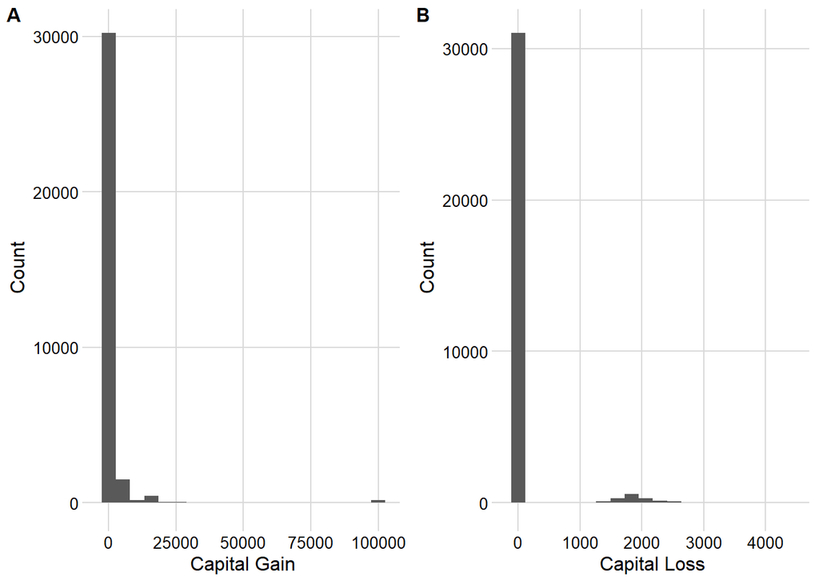

```r
# Remove scientific notation
options(scipen = 999)

# Histogram of Capital Gain
cg_plot <- ggplot(data = train_data, aes(x = capital_gain)) + geom_histogram(bins = 20) + labs(x = "Capital Gain", y = "Count") + theme(axis.title = element_text(family = "Arial"), plot.title = element_text(family = "Arial")) + theme_minimal_grid(12)

# Histogram of Capital Loss
cl_plot <- ggplot(data = train_data, aes(x = capital_loss)) + geom_histogram(bins = 20) + labs(x = "Capital Loss", y = "Count") + theme(axis.title = element_text(family = "Arial"), plot.title = element_text(family = "Arial")) + theme_minimal_grid(12)

# Use plot_grid() from cowplot to arrange plots on grid
plot_grid(cg_plot, cl_plot, labels = c('A', 'B'), label_size = 12)
```

Figure 1: Histograms of A) capital_gain and B) capital_loss.

Figure 1 reveals that the distributions of `capital_gain` and `capital_loss` are strongly skewed to the right, with most observations being zero. Therefore, we discard these two variables.

In addition, the frequency distribution of `native_country` shown below indicates that almost 90% (29170/32561) of all entries fall within the `United-States` category. Because of this heavy skewness, we exclude this variable from our analysis.

```r
# Frequencies of levels in native_country
summary(train_data$native_country)
```

```
                   Missing                   Cambodia
                       583                         19
                    Canada                      China
                       121                         75
                  Columbia                       Cuba
                        59                         95
        Dominican-Republic                    Ecuador
                        70                         28
               El-Salvador                    England
                       106                         90
                    France                    Germany
                        29                        137
                    Greece                  Guatemala
                        29                         64
                     Haiti         Holand-Netherlands
                        44                          1
                  Honduras                       Hong
                        13                         20
                   Hungary                      India
                        13                        100
                      Iran                    Ireland
                        43                         24
                     Italy                    Jamaica
                        73                         81
                     Japan                       Laos
                        62                         18
                    Mexico                  Nicaragua
                       643                         34
Outlying-US(Guam-USVI-etc)                       Peru
                        14                         31
               Philippines                     Poland
                       198                         60
                  Portugal                Puerto-Rico
                        37                        114
                  Scotland                      South
                        12                         80
                    Taiwan                   Thailand
                        51                         18
           Trinadad&Tobago              United-States
                        19                      29170
                   Vietnam                 Yugoslavia
                        67                         16
```

```r
# Drop non-informative columns
train_data$capital_gain <- NULL
train_data$capital_loss <- NULL
train_data$native_country <- NULL
```

**Task 5: Discard closely related independent variables.**

Two variables are considered collinear when they are so strongly correlated that it is difficult to determine their individual effects on the target variable. When this type of relationship occurs between more than two variables, we refer to it as multicollinearity. In the training dataset, `education` and `education_num` are collinear, as `education_num` is simply a numeric representation of `education`. The two variables contain the same information, so we discard one, i.e., `education_num`.

```r
# Drop one of a pair of collinear variables
train_data$education_num <- NULL
```

**Task 6: Discard variables that aren’t important to the analysis.**

Here, we discard `fnlwgt` and `relationship`.

```r
# Drop irrelevant variables
train_data$fnlwgt <- NULL
train_data$relationship <- NULL
```

**Task 7: Lump levels of independent categorical features with few observations.**

The independent categorical variables in the dataset are `workclass`, `education`, `marital_status`, `occupation`, `race`, and `sex`. We explore each of these variables to determine instances where level lumping can be applied to reduce the noise in the data.

**Lump `workclass` levels**

We use a barplot to compare the number of people belonging to each `workclass` level.

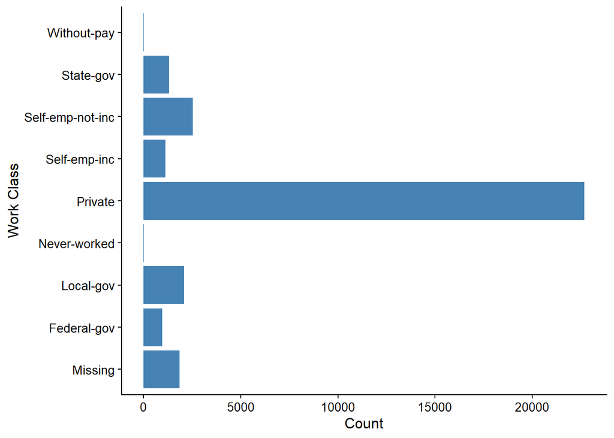

```r
# Barplot of workclass
wc_plot <- ggplot(data = train_data, aes(x = workclass)) + geom_bar(fill="steelblue") + labs(x = "Work Class", y = "Count") + theme(axis.title = element_text(family = "Arial")) + theme_cowplot(12) + coord_flip()

wc_plot
```

Figure 2: Barplot showing the distribution of people by workclass.

Figure 2 shows that the two levels, `Without-pay` and `Never-worked` have very few observations. So, we lump them together with the Missing in a level called “Other/Missing”. We also lump `State-gov`, `Local-gov`, and `Federal-gov` into a new level called “Gov,” as they all pertain to government-related work. `Self-emp-not-inc` and `Self-emp-inc` are consolidated into a new level called “Self-emp,” as both are related to self-employment.

```r
# Change names of workclass levels
train_data$workclass <- recode(train_data$workclass, "Missing" = "Other/Missing", "Federal-gov" = "Gov", "Local-gov" = "Gov", "Never-worked" = "Other/Missing", "Self-emp-inc" = "Self-emp", "Self-emp-not-inc" = "Self-emp", "State-gov" = "Gov", "Without-pay" = "Other/Missing")

# Check workclass level frequencies
table(train_data$workclass)
```

```
Other/Missing           Gov       Private      Self-emp
         1857          4351         22696          3657
```

We want the first (base) level of `workclass` to be a meaningful quantity that can later help with interpreting regression results. So, we use the `relevel()` function to reorder these levels, removing “Other/Missing” as the base level.

```r
train_data$workclass <- relevel(train_data$workclass, ref = "Gov")
```

**Lump `education` levels**

The barplot in Figure 3 explores the distribution of people by `education`. Here is the code used to create this plot:

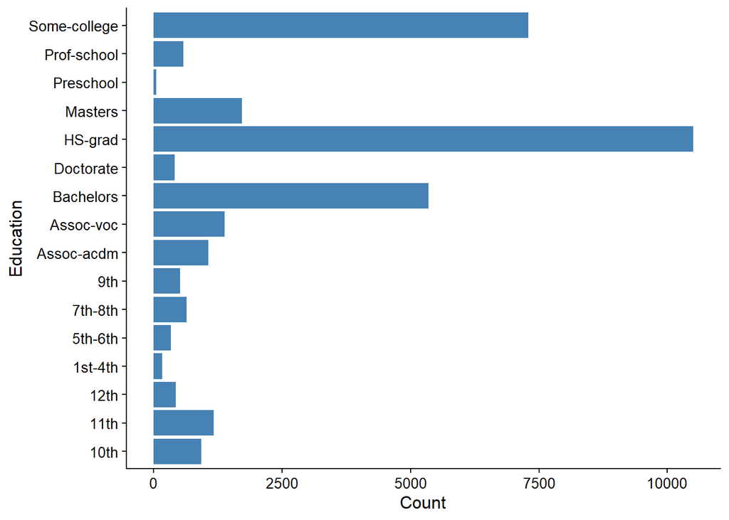

```r
# Barplot of education
ed_plot <- ggplot(data = train_data, aes(x = education)) + geom_bar(fill="steelblue") + labs(x = "Education", y = "Count") + theme(axis.title = element_text(family = "Arial")) + theme_cowplot(12) + coord_flip()

ed_plot
```

Figure 3: Barplot showing the distribution of people by education.

We see that all levels from `Preschool` to `12th grade` have somewhat low frequencies. So, we lump these levels into a new category called `Preschool-12th`. We also merge `Assoc-voc` and `Assoc-acdm` into a single level called `Associate`, as shown in the code below.

```r
# Recode education levels
train_data$education <- recode(train_data$education, "10th" = "Preschool-12th", "11th" = "Preschool-12th", "12th" = "Preschool-12th", "1st-4th" = "Preschool-12th", "5th-6th" = "Preschool-12th", "7th-8th" = "Preschool-12th", "9th" = "Preschool-12th", "Assoc-acdm" = "Associate", "Assoc-voc" = "Associate", "Preschool" = "Preschool-12th")

table(train_data$education)
```

```
Preschool-12th      Associate      Bachelors      Doctorate        HS-grad
          4253           2449           5355            413          10501
       Masters    Prof-school   Some-college
          1723            576           7291
```

**Lump `marital_status` levels**

The barplot in Figure 4 explores the distribution of people by `marital_status`.

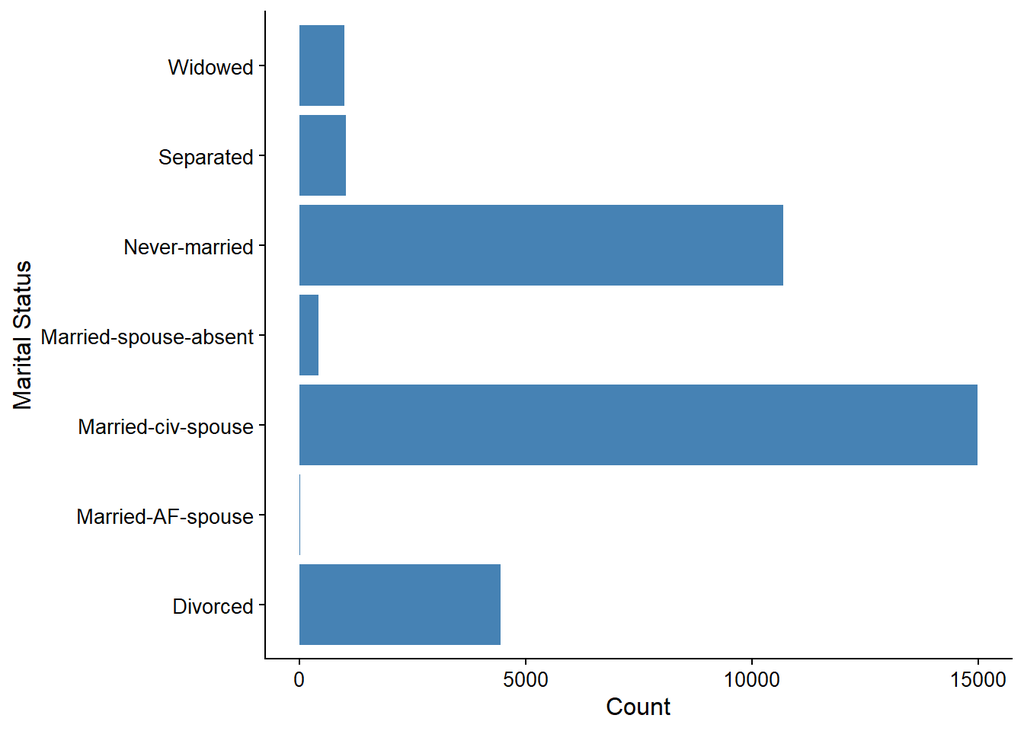

```r
# Barplot of marital_status
ms_plot <- ggplot(data = train_data, aes(x = marital_status)) + geom_bar(fill="steelblue") + labs(x = "Marital Status", y = "Count") + theme(axis.title = element_text(family = "Arial")) + theme_cowplot(12) + coord_flip()

ms_plot
```

Figure 4: Barplot showing the distribution of people by marital_status.

We lump `Married-spouse-absent`, `Married-civ-spouse`, and `Married-AF-spouse` into a level called “Married”, as they all denote married people. By doing so, we reduce the number of levels in this variable to 5.

```r
# Recode marital_status levels
train_data$marital_status <- recode(train_data$marital_status, "Married-AF-spouse" = "Married", "Married-civ-spouse" = "Married", "Married-spouse-absent" = "Married")

table(train_data$marital_status)
```

```
     Divorced       Married Never-married     Separated       Widowed
         4443         15417         10683          1025           993
```

**Lump `occupation` levels**

The barplot in Figure 5 illustrates the counts of people in each level of occupation. Here is the code used to create this plot.

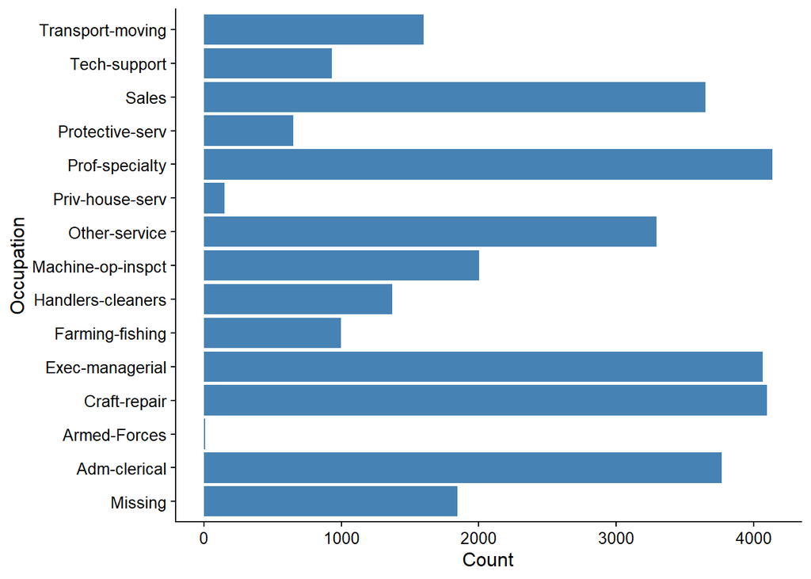

```r
oc_plot <- ggplot(data = train_data, aes(x = occupation)) + geom_bar(fill="steelblue") + labs(x = "Occupation", y = "Count") + theme(axis.title = element_text(family = "Arial")) + theme_cowplot(12) + coord_flip()

oc_plot
```

Figure 5: Barplot showing the distribution of people by occupation.

We create the following new levels for occupation:

1. Service-sales-workers: Protective-serv, Priv-house-serv, Other-service, Sales
2. Managers: Exec-managerial
3. Professionals: Prof-specialty
4. Technical: Tech-support
5. Clerical: Adm-clerical
6. Labor-trades: Machine-op-inspct, Handlers-cleaners, Farming-fishing, Craft-repair, Transport-moving
7. Others: Armed-Forces, Missing

```r
# Recode occupation levels
train_data$occupation <- recode(train_data$occupation, "Protective-serv" = "Service-sales-workers", "Sales" = "Service-sales-workers", "Priv-house-serv" = "Service-sales-workers", "Other-service" = "Service-sales-workers", "Exec-managerial" = "Managers", "Prof-specialty" = "Professionals", "Tech-support" = "Technical", "Adm-clerical" = "Clerical", "Machine-op-inspct" = "Labor-trades", "Handlers-cleaners" = "Labor-trades", "Farming-fishing" = "Labor-trades", "Craft-repair" = "Labor-trades", "Transport-moving" = "Labor-trades", "Armed-Forces" = "Other/Missing", "Missing" = "Other/Missing")

table(train_data$occupation)
```

```
        Other/Missing              Clerical          Labor-trades
                 1852                  3770                 10062
             Managers Service-sales-workers         Professionals
                 4066                  7743                  4140
            Technical
                  928
```

We also reorder the levels of occupation so that the first level is `Clerical`, a more meaningful quantity than `Other/Missing`.

```r
train_data$occupation <- relevel(train_data$occupation, ref = "Clerical")
```

**Lump `race` levels**

The barplot in Figure 6 shows the counts of people by `race`. Here is the code used to create it:

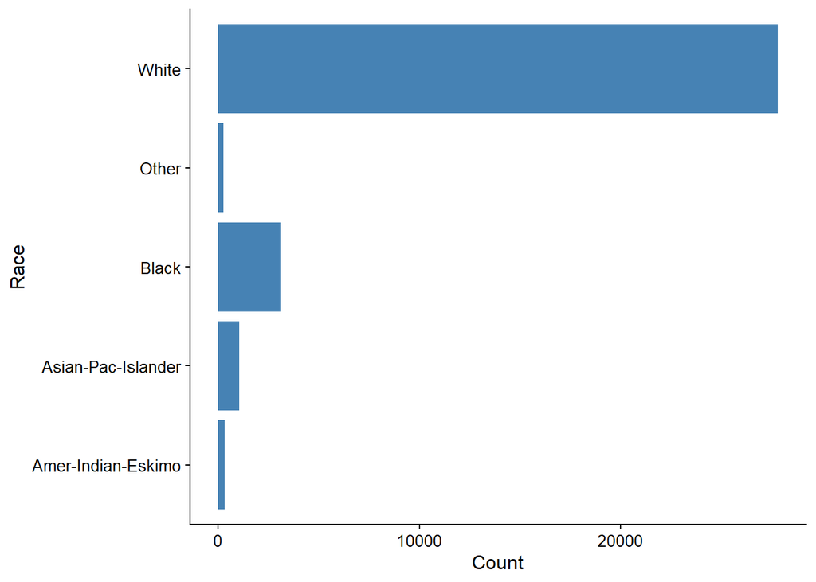

```r
r_plot <- ggplot(data = train_data, aes(x = race)) + geom_bar(fill="steelblue") + labs(x = "Race", y = "Count") + theme(axis.title = element_text(family = "Arial")) + theme_cowplot(12) + coord_flip()

r_plot
```

Figure 6: Barplot showing distribution of people by race.

We see that more than 20000 people are white, and the next most populous race is black, with less than 5000 people. To simplify our analysis, we regroup race into two levels, `White` and `Non-white`.

```r
# Recode race levels
train_data$race <- recode(train_data$race, "Amer-Indian-Eskimo" = "Non-white", "Asian-Pac-Islander" = "Non-white", "Black" = "Non-white", "Other" = "Non-white")

table(train_data$race)
```

```
Non-white     White
     4745     27816
```

**Lump `sex` levels**

Figure 7 shows the number of people in each level of `sex`. Here is the code used to create it:

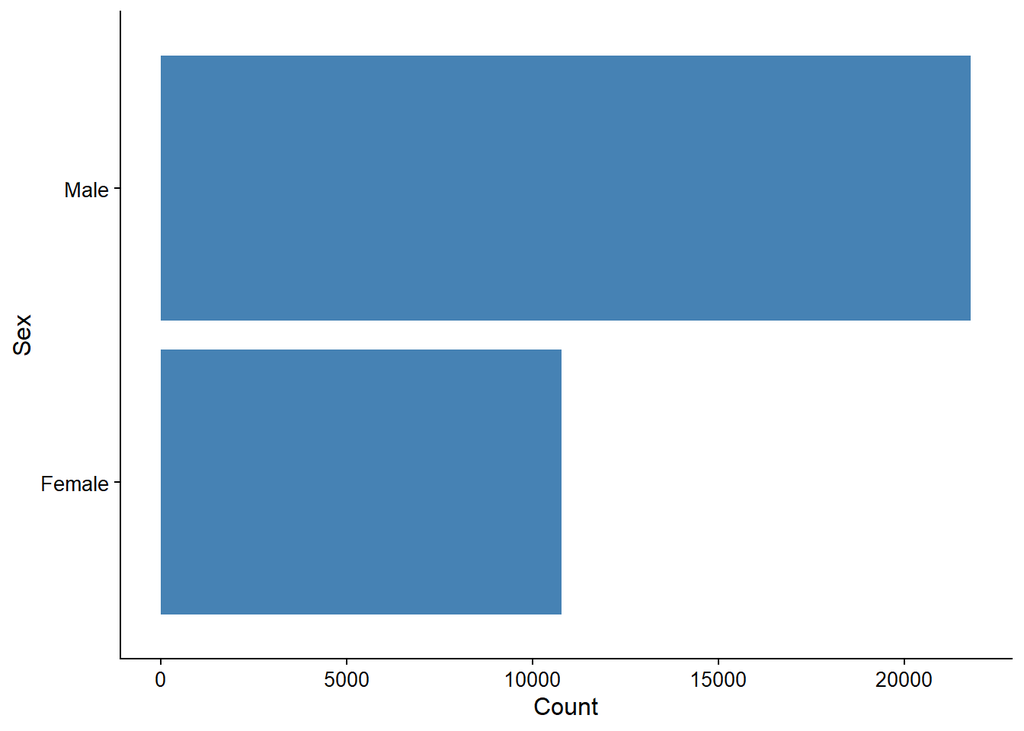

```r
s_plot <- ggplot(data = train_data, aes(x = sex)) + geom_bar(fill="steelblue") + labs(x = "Sex", y = "Count") + theme(axis.title = element_text(family = "Arial")) + theme_cowplot(12) + coord_flip()

s_plot
```

Figure 7: Barplot showing the distribution of people by sex.

We see that most people in the data are male. As `sex` only has two levels, both of which are important to the analysis, we don’t do any lumping here.

**Task 8: Study the relationship between income and each of the independent variables.**

Before we build our model, we want to see if there are specific differences between people with incomes <=50K and those with incomes >50K. So, we examine the relationship between income and each independent variable.

**Income vs. Age**

We use a histogram to determine the relationship between `age` and `income`.

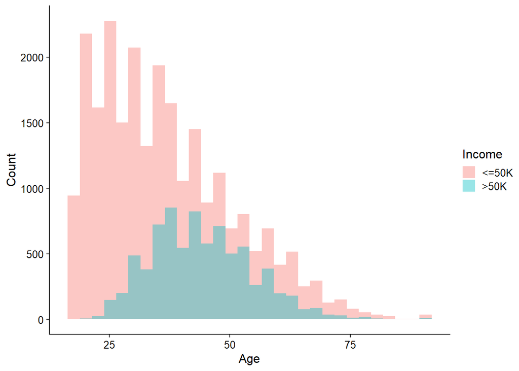

```r
age_plot <- ggplot(train_data, aes(x = age, fill = income)) +
    geom_histogram(position = "identity", alpha = 0.4, bins = 30) + labs(x = "Age", y = "Count", fill = "Income") + theme(axis.title = element_text(family = "Arial")) + theme_cowplot(12)

age_plot
```

Figure 8: Histogram showing the distribution of income by age.

Figure 8 shows that more people have incomes of `<=50K` than of `>50K`. The minimum age for people with incomes `<=50K` is slightly less than that for people of the other income group. Also, the distribution of ages in the `<=50K` group is heavily skewed to the right, suggesting that the mean age of this group is higher than the median age.

**Income Vs. workclass**

Here is the code used to create the proportional stacked barplot in Figure 9, showing the relationship between `workclass` and `income`:

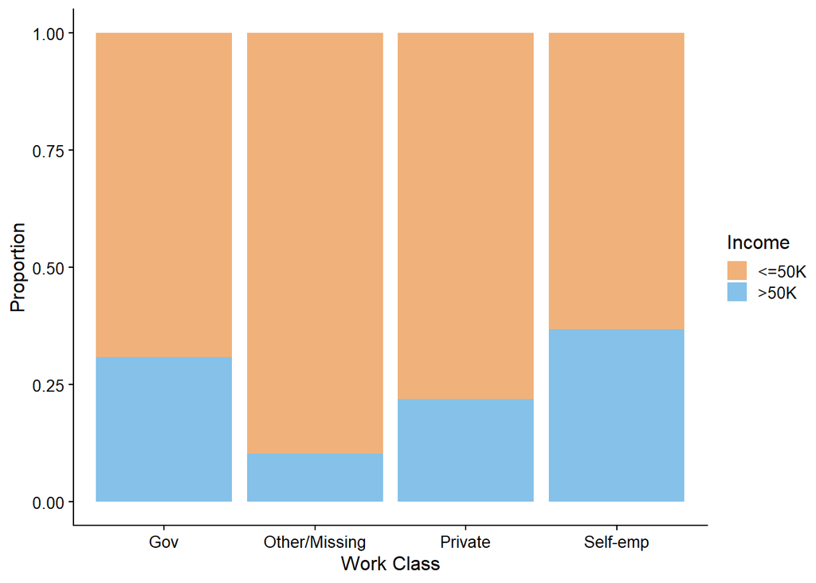

```r
wc_plot2 <- ggplot(data = train_data, aes(x = workclass, fill = income)) + geom_bar(position = "fill") + scale_fill_manual(values = c("#f0b27a", "#85c1e9")) + labs(x = "Work Class", y = "Proportion", fill = "Income") + theme(axis.title = element_text(family = "Arial")) + theme_cowplot(12)

wc_plot2
```

Figure 9: Barplot showing the distribution of income by workclass.

From the barplot, we see that the `workclass` with the highest proportion of `>50K` income earners is `Self-emp`, while that with the smallest proportion of this group of earners is `Other/Missing`.

**Income Vs. Education**

Here is the code for creating the barplot in Figure 10:

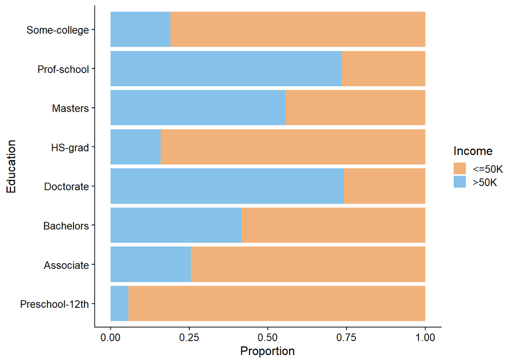

```r
ed_plot2 <- ggplot(data = train_data, aes(x = education, fill = income)) + geom_bar(position = "fill") + scale_fill_manual(values = c("#f0b27a", "#85c1e9")) + labs(x = "Education", y = "Proportion", fill = "Income") + theme(axis.title = element_text(family = "Arial")) + theme_cowplot(12) + coord_flip()

ed_plot2
```

Figure 10: Barplot showing the distribution of income by education.

The barplot reveals that the `Prof-school` and `Doctorate` levels of education have the highest proportions of people with an annual income `>50K`. Also, the proportion of `>50K` income earners appears to increase with an increase in the level of education.

**Income Vs. Marital Status**

We use the code below to create the barplot in Figure 11:

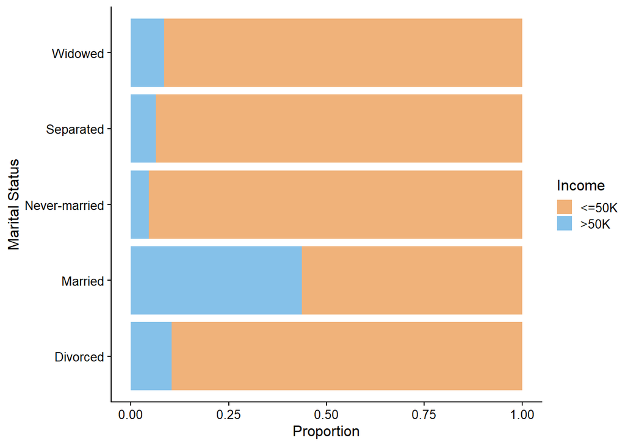

```r
ms_plot2 <- ggplot(data = train_data, aes(x = marital_status, fill = income)) + geom_bar(position = "fill") + scale_fill_manual(values = c("#f0b27a", "#85c1e9")) + labs(x = "Marital Status", y = "Proportion", fill = "Income") + theme(axis.title = element_text(family = "Arial")) + theme_cowplot(12) + coord_flip()

ms_plot2
```

Figure 11: Barplot showing the distribution of income by marital_status.

The barplot shows that the highest proportion of `>50K` income earners are found in the `Married` group, followed by the `Divorced`, `Widowed`, `Separated`, and `Never-married` groups, in that order.

**Income Vs. Occupation**

We create the barplot in Figure 12 using the following code:

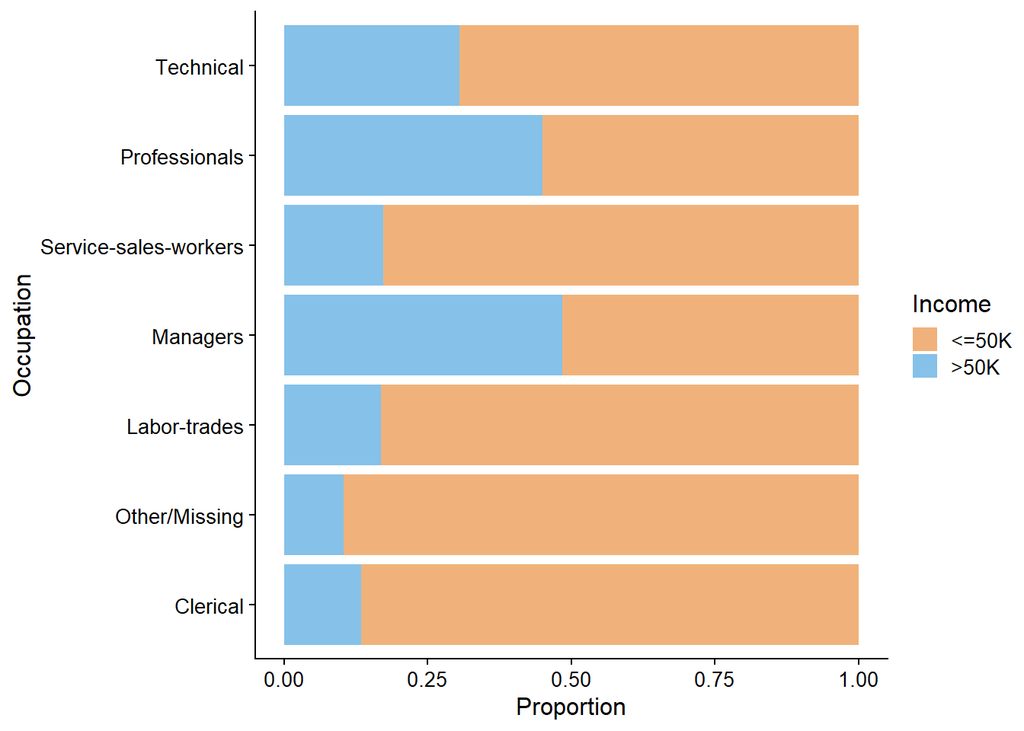

```r
oc_plot2 <- ggplot(data = train_data, aes(x = occupation, fill = income)) + geom_bar(position = "fill") + scale_fill_manual(values = c("#f0b27a", "#85c1e9")) + labs(x = "Occupation", y = "Proportion", fill = "Income") + theme(axis.title = element_text(family = "Arial")) + theme_cowplot(12) + coord_flip()

oc_plot2
```

Figure 12: Barplot showing the distribution of income by occupation.

From the barplot, we see that the highest proportion of `>50K` income earners are found in the `Managers` group, followed by the `Professionals` and `Technical` groups. The `Other/Missing` group has the lowest proportion of `>50K` income earners.

**Income Vs. Race**

The code below creates the barplot in Figure 13, showing the distribution of income across race levels.

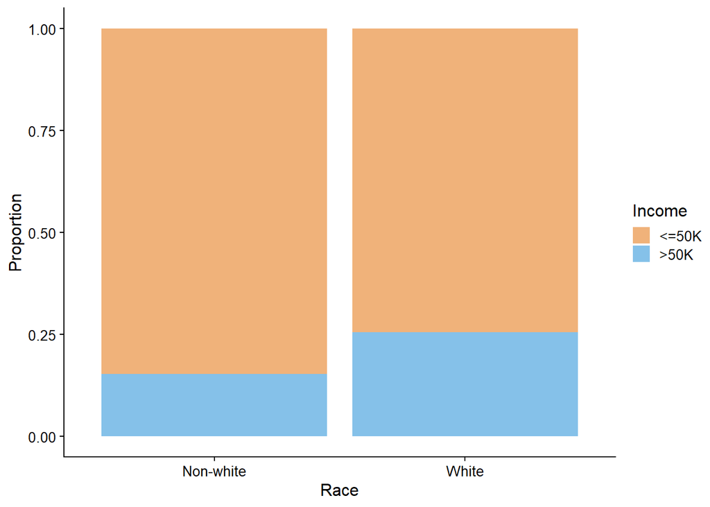

```r
r_plot2 <- ggplot(data = train_data, aes(x = race, fill = income)) + geom_bar(position = "fill") + scale_fill_manual(values = c("#f0b27a", "#85c1e9")) + labs(x = "Race", y = "Proportion", fill = "Income") + theme(axis.title = element_text(family = "Arial")) + theme_cowplot(12)

r_plot2
```

Figure 13: Barplot showing the distribution of income by race.

The barplot shows that the `White` group has a larger proportion of `>50K` income earners than the `Non-white` group.

**Income Vs. Hours/Week**

We use the code below to plot the histogram in Figure 14, showing the relationship between `income` and `hours_per_week`.

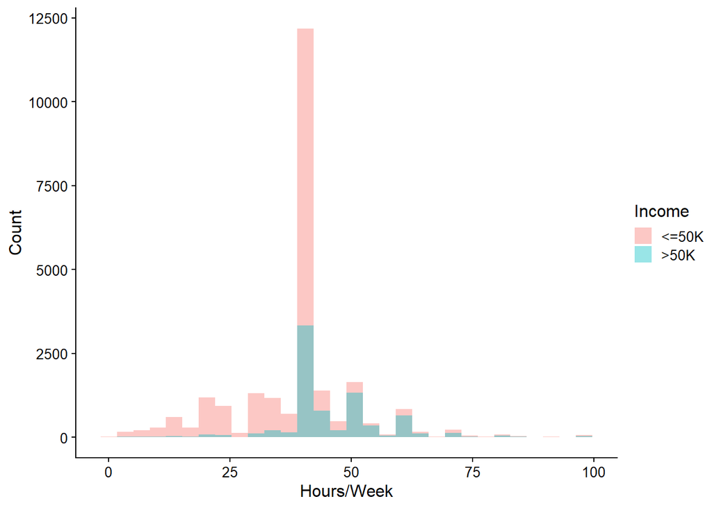

```r
hpw_plot <- ggplot(train_data, aes(x = hours_per_week, fill = income)) +
    geom_histogram(position = "identity", alpha = 0.4, bins = 30) + labs(x = "Hours/Week", y = "Count", fill = "Income") + theme(axis.title = element_text(family = "Arial")) + theme_cowplot(12)

hpw_plot
```

Figure 14: Histogram showing the distribution of income by hours_per_week.

From the histogram, we see that most people in the training data work about 40 hours/week. A large proportion of those who work less than 40 hours/week are `<=50K` income earners. However, looking at the distribution of the `>50K` income earners, the bars to the right of the 40 hours/week are longer than those to the left, meaning that many people in this income group work more than 40 hours/week.

## Build Model

**Task 9: Build a binary logistic regression model.**

We use the `glm()` function to build a model that predicts income group based on the variables `age`, `workclass`, `education`, `marital_status`, `occupation`, `race`, `sex`, and `hours_per_week`.

```r
options(scipen=0)
model1 <- glm(income ~ ., family = "binomial", data = train_data)
summary(model1)
```

```
Call:
glm(formula = income ~ ., family = "binomial", data = train_data)

Coefficients:
                                 Estimate Std. Error z value Pr(>|z|)
(Intercept)                     -6.914094   0.154482 -44.757  < 2e-16 ***
age                              0.028700   0.001488  19.291  < 2e-16 ***
workclassOther/Missing          -1.586627   0.745594  -2.128  0.03334 *
workclassPrivate                 0.051427   0.047502   1.083  0.27898
workclassSelf-emp               -0.202010   0.061587  -3.280  0.00104 **
educationAssociate               1.706695   0.089867  18.991  < 2e-16 ***
educationBachelors               2.315040   0.081844  28.286  < 2e-16 ***
educationDoctorate               3.310179   0.157257  21.049  < 2e-16 ***
educationHS-grad                 1.102238   0.076070  14.490  < 2e-16 ***
educationMasters                 2.677012   0.097854  27.357  < 2e-16 ***
educationProf-school             3.338942   0.139353  23.960  < 2e-16 ***
educationSome-college            1.481604   0.079442  18.650  < 2e-16 ***
marital_statusMarried            1.990770   0.060212  33.063  < 2e-16 ***
marital_statusNever-married     -0.510628   0.074723  -6.834 8.28e-12 ***
marital_statusSeparated         -0.143951   0.145438  -0.990  0.32228
marital_statusWidowed           -0.018087   0.134534  -0.134  0.89305
occupationOther/Missing          0.874156   0.746557   1.171  0.24163
occupationLabor-trades          -0.323266   0.067238  -4.808 1.53e-06 ***
occupationManagers               0.740283   0.069897  10.591  < 2e-16 ***
occupationService-sales-workers -0.054056   0.067894  -0.796  0.42593
occupationProfessionals          0.404060   0.073506   5.497 3.86e-08 ***
occupationTechnical              0.539975   0.103518   5.216 1.83e-07 ***
raceWhite                        0.280506   0.053006   5.292 1.21e-07 ***
sexMale                          0.313347   0.046955   6.673 2.50e-11 ***
hours_per_week                   0.030166   0.001460  20.655  < 2e-16 ***
---
Signif. codes:  0 '***' 0.001 '**' 0.01 '*' 0.05 '.' 0.1 ' ' 1

(Dispersion parameter for binomial family taken to be 1)

    Null deviance: 35948  on 32560  degrees of freedom
Residual deviance: 23743  on 32536  degrees of freedom
AIC: 23793

Number of Fisher Scoring iterations: 6
```

The model we’ve built above can be written algebraically as

$$\ln(\frac{\rho}{1-\rho}) = \beta_{0} +
\beta_{1}X_{1} + \cdots + \beta_{p}X_{p},$$

where $X_1, \cdots, X_p$ are the predictor variables, $β_0, \cdots ,β_p$ are the regression coefficients, $\rho$ is the probability of success, i.e., the probability of obtaining a particular value of the target variable, and $\frac{\rho}{1-\rho}$ is the odds for success.

The target, income, is a factor with two levels `<=50K` and `>50K`. R interprets the first level, `<=50K`, as failure and the second level, `>50K`, as success. For more information on how the `glm()` function handles the levels of factor variables, use the command `?glm` to access the function’s documentation pages.

For a continuous predictor, the regression coefficient gives the change in the log odds for success when the predictor increases by 1 unit. We can also say that the regression coefficient is the log of the odds ratio comparing people who differ in that predictor by 1 unit, when the remaining predictors are held fixed (UCLA: Statistical Consulting Group, n.d.). For example, from the regression output above,

- A 1 unit increase in `age` should result in a 0.029 increase in the log odds of income being `>50K`.
- A 1 unit increase in `hours_per_week` should result in a 0.030 increase in the log odds of income being `>50K`.

By contrast, the regression coefficient for a level of a categorical predictor gives the log of the odds ratio comparing people at the given level to those at the base level, when other predictors are held fixed. So, it is crucial for the base level to be a meaningful quantity.

From the regression output above, we can say that

- The log of the odds ratio for income being `>50K` comparing `males` to `females` is 0.313.
- The log of the odds ratio for income being `>50K` comparing `whites` to `non-whites` is 0.281.
- The log of the odds ratio for income being `>50K` comparing each level of education to the base level, `Pre-school-12th`, is greater than 1

We can also exponentiate the regression coefficients to give odd ratios. Here is the code:

```r
exp(coef(model1))
```

```
                    (Intercept)                             age
                   9.936811e-04                    1.029116e+00
         workclassOther/Missing                workclassPrivate
                   2.046146e-01                    1.052772e+00
              workclassSelf-emp              educationAssociate
                   8.170866e-01                    5.510721e+00
             educationBachelors              educationDoctorate
                   1.012533e+01                    2.739002e+01
               educationHS-grad                educationMasters
                   3.010897e+00                    1.454158e+01
           educationProf-school           educationSome-college
                   2.818928e+01                    4.399996e+00
          marital_statusMarried     marital_statusNever-married
                   7.321172e+00                    6.001186e-01
        marital_statusSeparated           marital_statusWidowed
                   8.659304e-01                    9.820751e-01
        occupationOther/Missing          occupationLabor-trades
                   2.396851e+00                    7.237814e-01
             occupationManagers occupationService-sales-workers
                   2.096528e+00                    9.473788e-01
        occupationProfessionals             occupationTechnical
                   1.497894e+00                    1.715964e+00
                      raceWhite                         sexMale
                   1.323799e+00                    1.367996e+00
                 hours_per_week
                   1.030626e+00
```

From the output above, we can now say that

- The odds of income being `>50K` increases by 1.029 when `age` increases by 1 unit.
- The odds of income being `>50K` increases by 1.031 when `hours_per_week` increases by 1 unit.
- The odds ratio for income being `>50K` comparing males to females is 1.368.
- The odds ratio for income being `>50K` comparing whites to non-whites is 1.324.
- The odds ratio for income being `>50K` comparing each level of education to the base level, `Pre-school-12th`, is greater than 1.

## Model Evaluation

**Task 10: Determine baseline accuracy**

We set the baseline accuracy as the proportion of the majority class because a naïve model is highly likely to always predict this class.

```r
round(nrow(train_data[train_data$income == '<=50K', ])/nrow(train_data), 2)
```

```
[1] 0.76
```

So, the baseline accuracy score is 0.76. Because the dataset is slightly imbalanced, with approximately 76% of the data belonging to the “<=50K” class, it’s better to use the balanced accuracy score to evaluate the performance of the logistic regression model. We explain how to calculate this and other evaluation metrics in **Task 11**.

**Task 11: Determine the training and test accuracies for the model.**

We can use the `predict()` function to get the probability of an individual earning a `>50K` income. If this probability is greater than 0.5, we assume that the individual earns a `>50K` income. Otherwise, they earn a `<=50K` income. We use the `confusionMatrix()` function from the `caret` package to compare the predicted income with the actual income.

```r
prob <- predict(model1, newdata = train_data, type = "response")
pred_income <- as.factor(ifelse(prob > 0.5, ">50K", "<=50K"))
confusionMatrix(pred_income, train_data$income)
```

```
Confusion Matrix and Statistics

          Reference
Prediction <=50K  >50K
     <=50K 22861  3753
     >50K   1859  4088

               Accuracy : 0.8276
                 95% CI : (0.8235, 0.8317)
    No Information Rate : 0.7592
    P-Value [Acc > NIR] : < 2.2e-16

                  Kappa : 0.4863

 Mcnemar's Test P-Value : < 2.2e-16

            Sensitivity : 0.9248
            Specificity : 0.5214
         Pos Pred Value : 0.8590
         Neg Pred Value : 0.6874
             Prevalence : 0.7592
         Detection Rate : 0.7021
   Detection Prevalence : 0.8174
      Balanced Accuracy : 0.7231

       'Positive' Class : <=50K
```

From the output above, we see that the train accuracy (0.8276) is better than the previously computed baseline accuracy, called the No Information Rate (0.7592) in the output.

Other important statistics generated by `confusionMatrix()` are defined below (Lee 2023):

- True positives (TP): the number of events the model correctly classifies as positive. In this case, TP = 22861.
- True negatives (TN): the number of events the model correctly classifies as negative. In this case, TN = 4088.
- False positives (FP): the number of events the model incorrectly classifies as positive. In this case, FP = 3753.
- False negatives (FN): the number of events the model incorrectly classifies as negative. In this case, FN = 1859.
- P-Value [Acc > NIR]: the p value of a statistical test indicating whether the model’s accuracy is significantly better than the NIR.
- Kappa (also called Cohen’s kappa): a measure of how well the model’s predictions agree with actual values. It ranges from -1 to 1. A less than 0 value suggests an agreement worse than chance, and a greater than 0 value suggests an agreement better than chance.
- Mcnemar’s Test P-Value: the p value of a statistical test comparing the number of false positives to false negatives. A large p value suggests no significant difference between the two groups.
- Sensitivity (also called recall or true positive rate): the proportion of actual positive events correctly classified by the model. It is calculated as $\frac{TP}{TP + FN}$.
- Specificity (also called true negative rate): the proportion of actual negative events correctly classified by the model. It is calculated as $\frac{TN}{FP + TN}$
- Positive predictive value (also called precision): the proportion of positive predictions that were true. It is calculated as $\frac{TP}{TP + FP}$.
- Negative Predictive Value: the proportion of negative predictions that were true. It is calculated as $\frac{TN}{TN + FN}$.
- Prevalence: the proportion of actually positive events in the dataset. It is the same as the “No Information Rate” also given in this output and calculated as $\frac{TP + FN}{TP + FP + TN + FN}$
- Detection Rate: the proportion of true positives in the dataset. It is calculated as $\frac{TP}{TP + FP + TN + FN}$.
- Detection Prevalence: the proportion of events predicted as positive. It is calculated as $\frac{TP + FP}{TP + FP + TN + FN}$.
- Balanced Accuracy: the average of specificity and sensitivity.

As we’ve already mentioned, instead of using the standard accuracy score to evaluate the model’s performance, we can use the balanced accuracy, which is a more reliable measure of performance when dealing with imbalanced datasets. The balanced accuracy score for the baseline model is 0.5, while that for the logistic regression model is 0.7231. This result suggests that the model has learned meaningful patterns from the data and is not merely guessing the majority class.

Next, we look at the model’s performance on the test data. But we must first import the data and transform it the same way we transformed the training data.

```r
# Read test data.
# We skip the first line of the dataset (skip = 1) because it doesn’t
# contain useful information.
test_data <- read.csv("C:/Users/User/Desktop/Logistic_Regression_ADULT/Data/adult.test", skip = 1, header = FALSE, sep = ",", strip.white = TRUE, stringsAsFactors = TRUE)
# Name columns
names(test_data) <- c("age", "workclass", "fnlwgt", "education", "education_num", "marital_status", "occupation", "relationship", "race", "sex", "capital_gain", "capital_loss", "hours_per_week", "native_country", "income")
```

Get an overview of the test data:

```r
str(test_data)
```

```
'data.frame':   16281 obs. of  15 variables:
 $ age           : int  25 38 28 44 18 34 29 63 24 55 ...
 $ workclass     : Factor w/ 9 levels "?","Federal-gov",..: 5 5 3 5 1 5 1 7 5 5 ...
 $ fnlwgt        : int  226802 89814 336951 160323 103497 198693 227026 104626 369667 104996 ...
 $ education     : Factor w/ 16 levels "10th","11th",..: 2 12 8 16 16 1 12 15 16 6 ...
 $ education_num : int  7 9 12 10 10 6 9 15 10 4 ...
 $ marital_status: Factor w/ 7 levels "Divorced","Married-AF-spouse",..: 5 3 3 3 5 5 5 3 5 3 ...
 $ occupation    : Factor w/ 15 levels "?","Adm-clerical",..: 8 6 12 8 1 9 1 11 9 4 ...
 $ relationship  : Factor w/ 6 levels "Husband","Not-in-family",..: 4 1 1 1 4 2 5 1 5 1 ...
 $ race          : Factor w/ 5 levels "Amer-Indian-Eskimo",..: 3 5 5 3 5 5 3 5 5 5 ...
 $ sex           : Factor w/ 2 levels "Female","Male": 2 2 2 2 1 2 2 2 1 2 ...
 $ capital_gain  : int  0 0 0 7688 0 0 0 3103 0 0 ...
 $ capital_loss  : int  0 0 0 0 0 0 0 0 0 0 ...
 $ hours_per_week: int  40 50 40 40 30 30 40 32 40 10 ...
 $ native_country: Factor w/ 41 levels "?","Cambodia",..: 39 39 39 39 39 39 39 39 39 39 ...
 $ income        : Factor w/ 2 levels "<=50K.",">50K.": 1 1 2 2 1 1 1 2 1 1 ...
```

First, we get rid of all the variables we don’t need, i.e., `capital_gain`, `capital_loss`, `native_country`, `education_num`, `fnlwgt`, and `relationship`.

```r
test_data$capital_gain <- NULL
test_data$capital_loss <- NULL
test_data$native_country <- NULL
test_data$education_num <- NULL
test_data$fnlwgt <- NULL
test_data$relationship <- NULL
```

Next, we use the `recode()` function from the `dplyr` package to recode missing values and lump predictor levels.

**Lump `workclass` levels**

```r
test_data$workclass <- recode(test_data$workclass, "?" = "Other/Missing", "Federal-gov" = "Gov", "Local-gov" = "Gov", "Never-worked" = "Other/Missing", "Self-emp-inc" = "Self-emp", "Self-emp-not-inc" = "Self-emp", "State-gov" = "Gov", "Without-pay" = "Other/Missing")
```

Next, we make “Gov” the base level of the variable.

```r
test_data$workclass <- relevel(test_data$workclass, ref = "Gov")
```

**Lump `education` levels**

```r
test_data$education <- recode(test_data$education, "10th" = "Preschool-12th", "11th" = "Preschool-12th", "12th" = "Preschool-12th", "1st-4th" = "Preschool-12th", "5th-6th" = "Preschool-12th", "7th-8th" = "Preschool-12th", "9th" = "Preschool-12th", "Assoc-acdm" = "Associate", "Assoc-voc" = "Associate", "Preschool" = "Preschool-12th")
```

**Lump `marital_status` levels**

```r
test_data$marital_status <- recode(test_data$marital_status, "Married-AF-spouse" = "Married", "Married-civ-spouse" = "Married", "Married-spouse-absent" = "Married")
```

**Lump `occupation` levels**

```r
test_data$occupation <- recode(test_data$occupation, "Protective-serv" = "Service-sales-workers", "Sales" = "Service-sales-workers", "Priv-house-serv" = "Service-sales-workers", "Other-service" = "Service-sales-workers", "Exec-managerial" = "Managers", "Prof-specialty" = "Professionals", "Tech-support" = "Technical", "Adm-clerical" = "Clerical", "Machine-op-inspct" = "Labor-trades", "Handlers-cleaners" = "Labor-trades", "Farming-fishing" = "Labor-trades", "Craft-repair" = "Labor-trades", "Transport-moving" = "Labor-trades", "Armed-Forces" = "Other/Missing", "?" = "Other/Missing")
```

Next, we reorder occupation levels to make `Clerical` the base level.

```r
test_data$occupation <- relevel(test_data$occupation, ref = "Clerical")
```

**Lump `race` levels**

```r
test_data$race <- recode(test_data$race, "Amer-Indian-Eskimo" = "Non-white", "Asian-Pac-Islander" = "Non-white", "Black" = "Non-white", "Other" = "Non-white")
```

**Clean `income` levels**

We remove the dots in `income` level names, as shown below.

```r
test_data$income <- recode(test_data$income, "<=50K." = "<=50K", ">50K." = ">50K")
```

Having cleaned the test dataset, we can now use the `predict()` function to make predictions on the test set. We then use `confusionMatrix()` to compute the test accuracy score and other metrics.

```r
prob_test <- predict(model1, newdata = test_data, type = "response")
pred_income_test <- as.factor(ifelse(prob_test > 0.5, ">50K", "<=50K"))
confusionMatrix(pred_income_test, test_data$income)
```

```
Confusion Matrix and Statistics

          Reference
Prediction <=50K  >50K
     <=50K 11498  1827
     >50K    937  2019

               Accuracy : 0.8302
                 95% CI : (0.8244, 0.836)
    No Information Rate : 0.7638
    P-Value [Acc > NIR] : < 2.2e-16

                  Kappa : 0.4887

 Mcnemar's Test P-Value : < 2.2e-16

            Sensitivity : 0.9246
            Specificity : 0.5250
         Pos Pred Value : 0.8629
         Neg Pred Value : 0.6830
             Prevalence : 0.7638
         Detection Rate : 0.7062
   Detection Prevalence : 0.8184
      Balanced Accuracy : 0.7248

       'Positive' Class : <=50K
```

From the output above, we see that the test accuracy is 0.83, which is slightly better than the train accuracy. Also, the test balanced accuracy (0.7248) is slightly higher than the training balanced accuracy (0.7231). So, we can conclude that the model probably generalizes well on new data.

## References

Becker, Barry, and Ronny Kohavi. 1996. “Adult.” UCI Machine Learning Repository.

Boehmke, Brad, and Brandon M. Greenwell. 2019. *Hands-on Machine Learning with R*. New York: CRC Press.

Lee, Changjun. 2023. “Understanding the Confusion Matrix and ROC Curve in R.” https://changjunlee.com/blogs/posts/4_confusion_mat_and_roc.

UCLA: Statistical Consulting Group. n.d. “Logit Regression | R Data Analysis Examples.” https://stats.oarc.ucla.edu/r/dae/logit-regression/.